### Q1 a)

#### There are no missing values in the dataset. Numeric variables:Age, Medu, Fedu, traveltime, studytime, failures, famrel, freetime, goout, Dalc, Walc, Health, absences, G1, G2. Categorical Variables: school, sex, address, famsize, Pstatus, Mjob, Fjob, reason, guardian, schoolsup, famsup, paid, activities, nursery, higher, internet, romantic. Response Variable:G3. Except the response variable rest all variables are the predictors.

### Q2 a)

```r
dataset=read.csv('student-mat.csv',header=T, sep=";")

dataset_new=data.frame(dataset$age,dataset$address,dataset$Pstatus,
                     dataset$activities,dataset$higher,dataset$internet,dataset$absences,dataset$G1,
                     dataset$G2,dataset$G3)
colnames(dataset_new)<-c('age','address','Pstatus',
                     'activities','higher','internet','absences','G1',
                     'G2','G3')
dataset_new_numeric=data.frame(dataset$age,dataset$absences,dataset$G1,
                     dataset$G2,dataset$G3)
colnames(dataset_new_numeric)<-c('age','absences','G1',
                     'G2','G3'
                     )
dataset_new_categorical=data.frame(dataset$address,dataset$Pstatus,
                     dataset$activities,dataset$higher,dataset$internet)
colnames(dataset_new_categorical)<-c('address','Pstatus',
                     'activities','higher','internet' )
j=1
for(i in dataset_new_numeric){
print(attributes(dataset_new_numeric)$names[j])
print(summary(i))
print("Standard deviation: ")
print(sd(i))
j=j+1

}
```

```
## [1] "age"
##    Min. 1st Qu.  Median    Mean 3rd Qu.    Max.
##    15.0    16.0    17.0    16.7    18.0    22.0
## [1] "Standard deviation: "
## [1] 1.276043
## [1] "absences"
##    Min. 1st Qu.  Median    Mean 3rd Qu.    Max.
##   0.000   0.000   4.000   5.709   8.000  75.000
## [1] "Standard deviation: "
## [1] 8.003096
## [1] "G1"
##    Min. 1st Qu.  Median    Mean 3rd Qu.    Max.
##    3.00    8.00   11.00   10.91   13.00   19.00
## [1] "Standard deviation: "
## [1] 3.319195
## [1] "G2"
##    Min. 1st Qu.  Median    Mean 3rd Qu.    Max.
##    0.00    9.00   11.00   10.71   13.00   19.00
## [1] "Standard deviation: "
## [1] 3.761505
## [1] "G3"
##    Min. 1st Qu.  Median    Mean 3rd Qu.    Max.
##    0.00    8.00   11.00   10.42   14.00   20.00
## [1] "Standard deviation: "
## [1] 4.581443
```

### Q2 b)

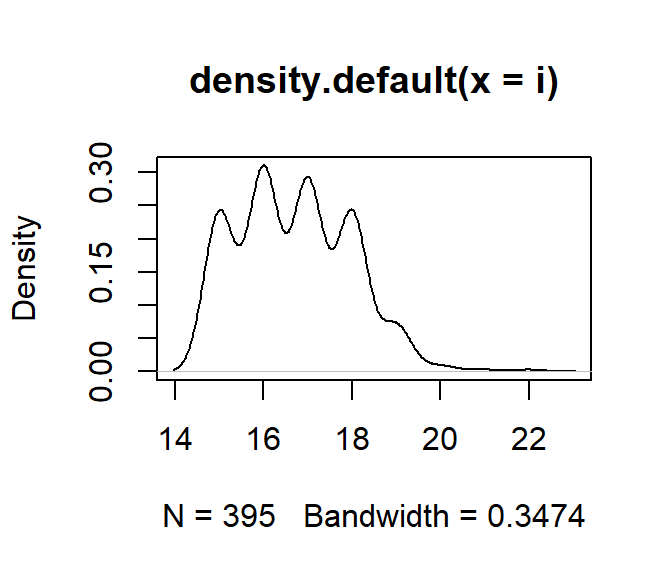

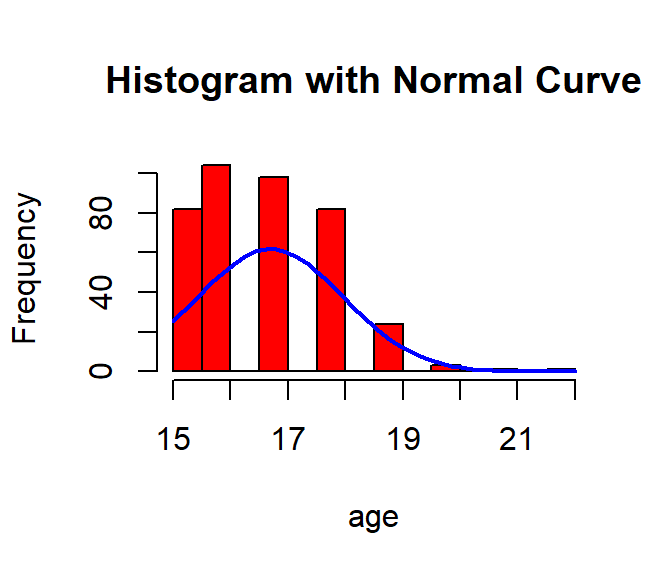

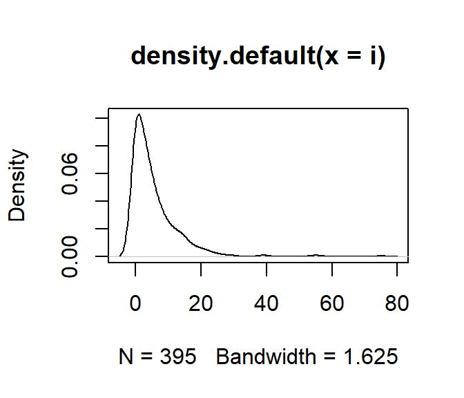

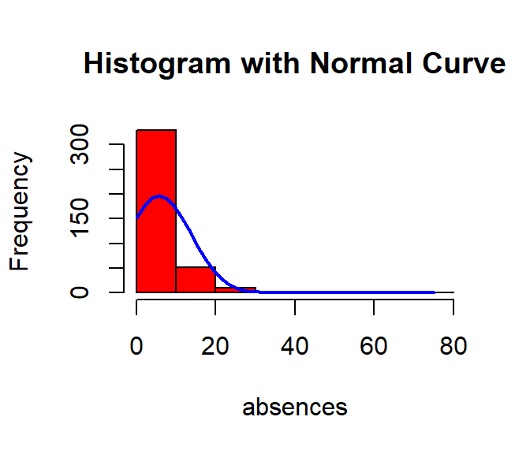

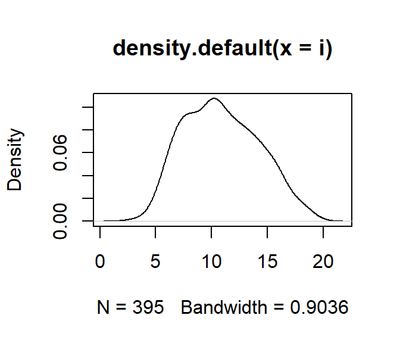

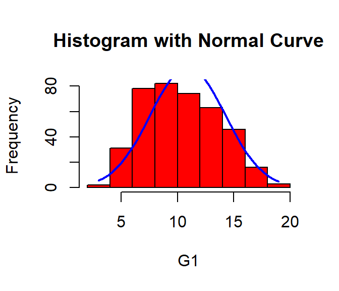

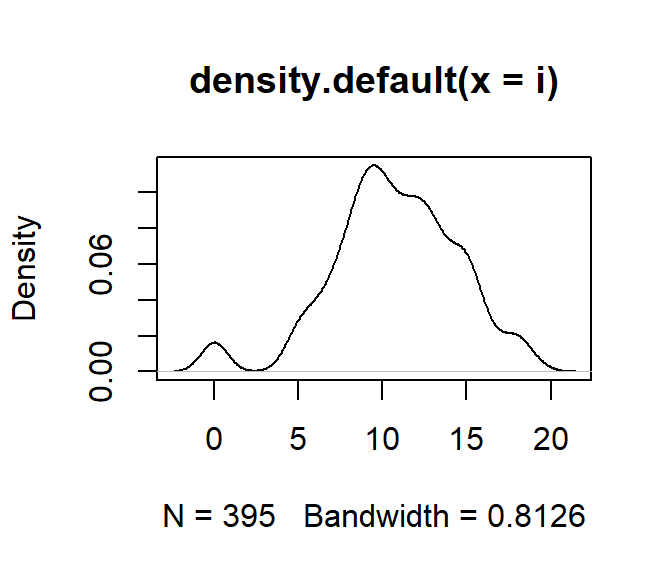

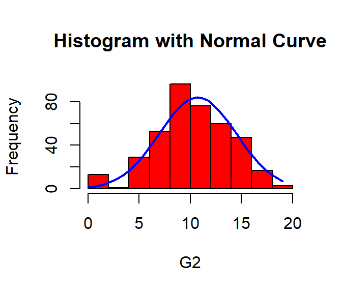

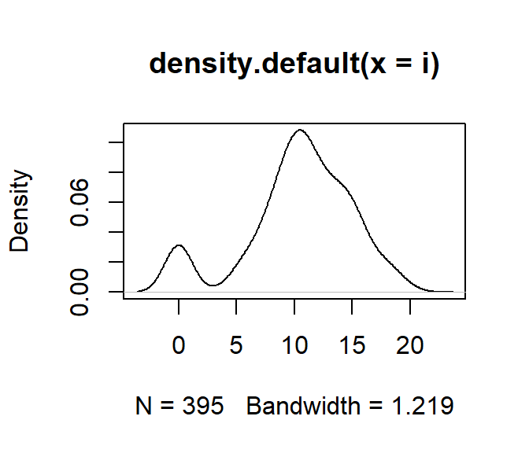

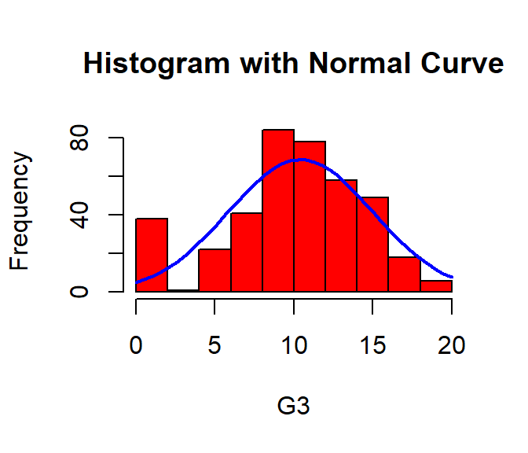

```r
library('ggplot2')
theme_set(theme_bw())


j=1
for (i in dataset_new_numeric) {
x <- i
plot(density(i))
y=attributes(dataset_new_numeric)$names[j]
h<-hist(x, breaks=10, col="red", xlab=y,
    main="Histogram with Normal Curve")
xfit<-seq(min(x),max(x),length=40)
yfit<-dnorm(xfit,mean=mean(x),sd=sd(x))
yfit <- yfit*diff(h$mids[1:2])*length(x)
lines(xfit, yfit, col="blue", lwd=2)
j=j+1
}
```

### Q2 c)

```r
cor(dataset_new_numeric)
```

```
##                 age    absences         G1         G2          G3
## age       1.0000000  0.17523008 -0.0640815 -0.1434740 -0.16157944
## absences  0.1752301  1.00000000 -0.0310029 -0.0317767  0.03424732
## G1       -0.0640815 -0.03100290  1.0000000  0.8521181  0.80146793
## G2       -0.1434740 -0.03177670  0.8521181  1.0000000  0.90486799
## G3       -0.1615794  0.03424732  0.8014679  0.9048680  1.00000000
```

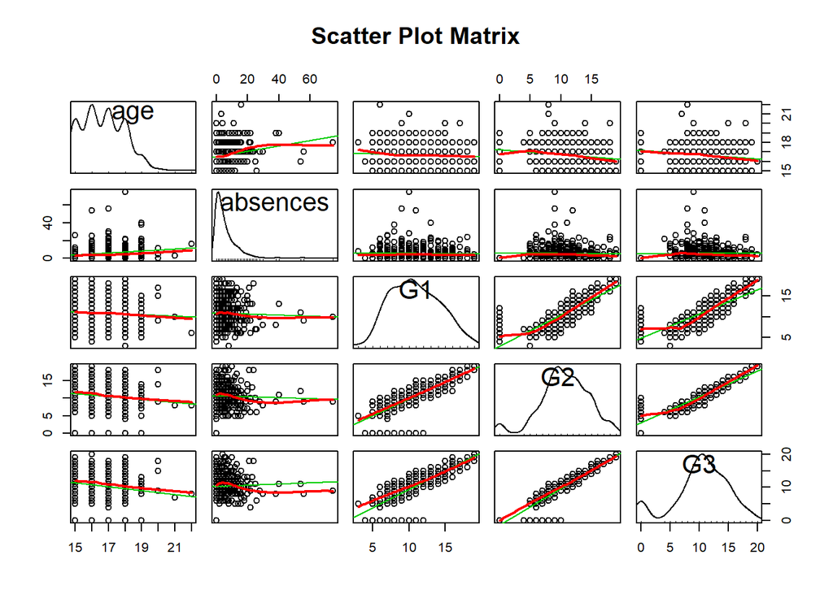

```r
library(car)
suppressWarnings( ## (avoid printing the warnings)
scatterplotMatrix(dataset_new_numeric, spread=FALSE, lty.smooth=2,
                  main="Scatter Plot Matrix")
)
```

#### The variables G1 and G2 are linearly positively correlated to target variable G3 i.e value of G3 increases with G1 and G2. The variables age and absences are not correlated to G3.

### Q2 d)

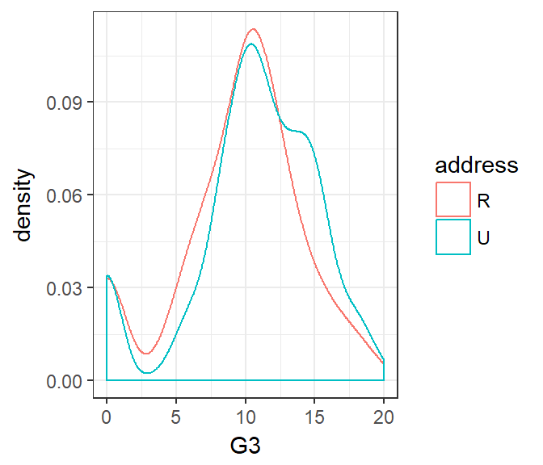

```r
G3=dataset_new_numeric$G3
library(ggplot2)
theme_set(theme_bw())

  address=dataset_new_categorical$address
ggplot(data =dataset_new) +
   geom_density(mapping = aes(x = G3, color = address))
```

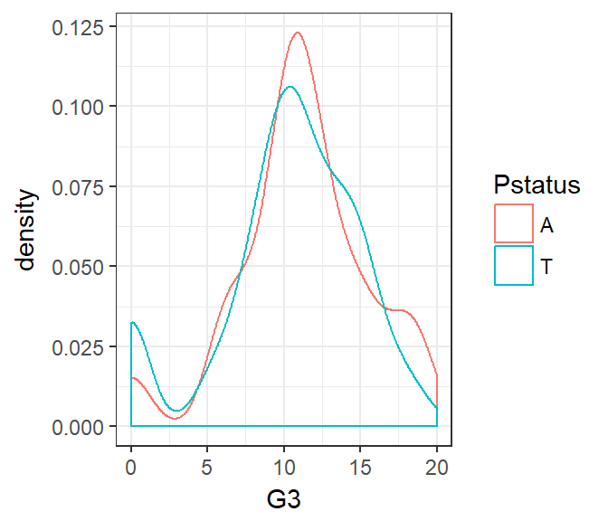

```r
 Pstatus=dataset_new_categorical$Pstatus
ggplot(data =dataset_new) +
   geom_density(mapping = aes(x = G3, color = Pstatus))
```

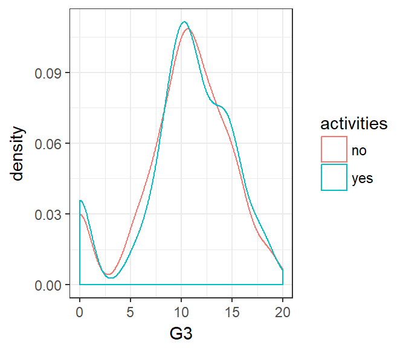

```r
 activities=dataset_new_categorical$activities
ggplot(data =dataset_new) +
   geom_density(mapping = aes(x = G3, color = activities))
```

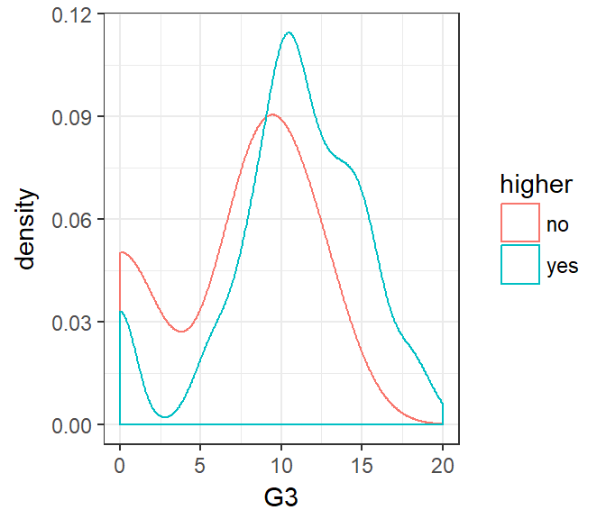

```r
 higher=dataset_new_categorical$higher
ggplot(data =dataset_new) +
   geom_density(mapping = aes(x = G3, color = higher))
```

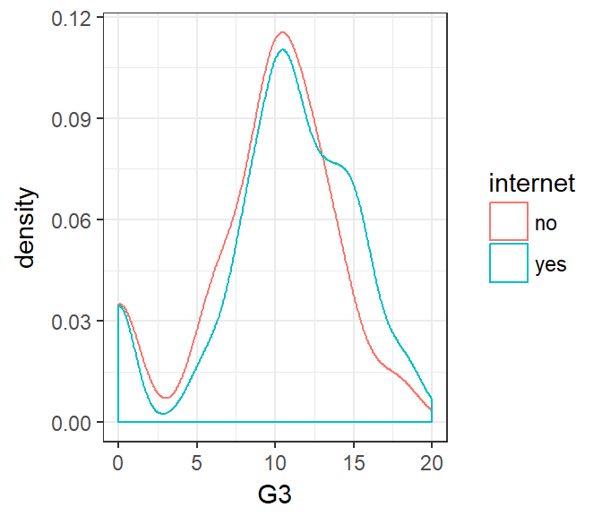

```r
 internet=dataset_new_categorical$internet
ggplot(data =dataset_new) +
   geom_density(mapping = aes(x = G3, color= internet))
```

### Q2 e)

#### The density distribution of response variable is same for students with and without extra-curricular activities. Hence response variable is not significantly different for students with and without extra-curricular activities.

### Q3 a)

```r
fit = lm(G3 ~ school + sex + age + address +  famsize + Pstatus + Medu + Fedu + Mjob + Fjob + reason + guardian + traveltime+ studytime + failures + schoolsup + famsup + paid + activities + nursery + higher + internet + romantic + famrel + freetime + goout + Dalc + Walc + health + absences + G1 + G2, data=dataset)
summary(fit)
```

```
##
## Call:
## lm(formula = G3 ~ school + sex + age + address + famsize + Pstatus +
##     Medu + Fedu + Mjob + Fjob + reason + guardian + traveltime +
##     studytime + failures + schoolsup + famsup + paid + activities +
##     nursery + higher + internet + romantic + famrel + freetime +
##     goout + Dalc + Walc + health + absences + G1 + G2, data = dataset)
##
## Residuals:
##     Min      1Q  Median      3Q     Max
## -7.9339 -0.5532  0.2680  0.9689  4.6461
##
## Coefficients:
##                   Estimate Std. Error t value Pr(>|t|)
## (Intercept)      -1.115488   2.116958  -0.527 0.598573
## schoolMS          0.480742   0.366512   1.312 0.190485
## sexM              0.174396   0.233588   0.747 0.455805
## age              -0.173302   0.100780  -1.720 0.086380 .
## addressU          0.104455   0.270791   0.386 0.699922
## famsizeLE3        0.036512   0.226680   0.161 0.872128
## PstatusT         -0.127673   0.335626  -0.380 0.703875
## Medu              0.129685   0.149999   0.865 0.387859
## Fedu             -0.133940   0.128768  -1.040 0.298974
## Mjobhealth       -0.146426   0.518491  -0.282 0.777796
## Mjobother         0.074088   0.332044   0.223 0.823565
## Mjobservices      0.046956   0.369587   0.127 0.898973
## Mjobteacher      -0.026276   0.481632  -0.055 0.956522
## Fjobhealth        0.330948   0.666601   0.496 0.619871
## Fjobother        -0.083582   0.476796  -0.175 0.860945
## Fjobservices     -0.322142   0.493265  -0.653 0.514130
## Fjobteacher      -0.112364   0.601448  -0.187 0.851907
## reasonhome       -0.209183   0.256392  -0.816 0.415123
## reasonother       0.307554   0.380214   0.809 0.419120
## reasonreputation  0.129106   0.267254   0.483 0.629335
## guardianmother    0.195741   0.252672   0.775 0.439046
## guardianother     0.006565   0.463650   0.014 0.988710
## traveltime        0.096994   0.157800   0.615 0.539170
## studytime        -0.104754   0.134814  -0.777 0.437667
## failures         -0.160539   0.161006  -0.997 0.319399
## schoolsupyes      0.456448   0.319538   1.428 0.154043
## famsupyes         0.176870   0.224204   0.789 0.430710
## paidyes           0.075764   0.222100   0.341 0.733211
## activitiesyes    -0.346047   0.205938  -1.680 0.093774 .
## nurseryyes       -0.222716   0.254184  -0.876 0.381518
## higheryes         0.225921   0.500398   0.451 0.651919
## internetyes      -0.144462   0.287528  -0.502 0.615679
## romanticyes      -0.272008   0.219732  -1.238 0.216572
## famrel            0.356876   0.114124   3.127 0.001912 **
## freetime          0.047002   0.110209   0.426 0.670021
## goout             0.012007   0.105230   0.114 0.909224
## Dalc             -0.185019   0.153124  -1.208 0.227741
## Walc              0.176772   0.114943   1.538 0.124966
## health            0.062995   0.074800   0.842 0.400259
## absences          0.045879   0.013412   3.421 0.000698 ***
## G1                0.188847   0.062373   3.028 0.002645 **
## G2                0.957330   0.053460  17.907  < 2e-16 ***
## ---
## Signif. codes:  0 '***' 0.001 '**' 0.01 '*' 0.05 '.' 0.1 ' ' 1
##
## Residual standard error: 1.901 on 353 degrees of freedom
## Multiple R-squared:  0.8458, Adjusted R-squared:  0.8279
## F-statistic: 47.21 on 41 and 353 DF,  p-value: < 2.2e-16
```

```r
y=dataset$G3
mean.mse = mean((rep(mean(y),length(y)) - y)^2)
model.mse = mean(residuals(fit)^2)
rmse = sqrt(model.mse)
rmse
```

```
## [1] 1.796979
```

```r
r2 = 1 - (model.mse / mean.mse)
r2
```

```
## [1] 0.8457652
```

#### Multiple R-squared value is 0.8458. It means that it has 84.58% correlation between actual and predicted outcome. Its P value is almost equivalent to zero which shows that the model is significant. Adjusted R-squared is more reiable measure, since it takes into account all the variables.

### Q3 b)

```r
n = length(dataset$G3)
error = dim(n)
for (k in 1:n) {
  train1 = c(1:n)
  train = train1[train1!=k] ## pick elements that are different from k
  m2 = lm(G3 ~ school + sex + age + address + Pstatus + Medu + Fedu + Mjob + Fjob +
  traveltime + studytime + failures + absences + G1 + G2 , data=dataset[train,])
  pred = predict(m2, newdat=dataset[-train ,])
  obs = dataset$G3[-train]
  error[k] = obs-pred
}
me=mean(error)
me
```

```
## [1] -0.0007369704
```

```r
rmse=sqrt(mean(error^2))
rmse
```

```
## [1] 1.968539
```

```r
# setB
n = length(dataset$G3)
error = dim(n)
for (k in 1:n) {
  train1 = c(1:n)
  train = train1[train1!=k] ## pick elements that are different from k
  m2 = lm(G3 ~  school + sex + age + studytime + failures + absences + G1 + G2 , data=dataset[train,])
  pred = predict(m2, newdat=dataset[-train ,])
  obs = dataset$G3[-train]
  error[k] = obs-pred
}
me=mean(error)
me
```

```
## [1] -0.002483432
```

```r
rmse=sqrt(mean(error^2))
rmse
```

```
## [1] 1.928921
```

```r
#fit2 = lm(G3 ~ school + sex + age + studytime + failures + absences + G1 + G2, data=dataset)
#summary(fit2)

#fit3= lm(G3 ~ school + sex + age + address + Pstatus + Medu + Fedu + Mjob + Fjob + traveltime + G1 + G2, data=dataset)
#summary(fit3)
n = length(dataset$G3)
error = dim(n)
for (k in 1:n) {
  train1 = c(1:n)
  train = train1[train1!=k] ## pick elements that are different from k
  m2 = lm(G3 ~  school + sex + age + address + Pstatus + Medu + Fedu + Mjob + Fjob + traveltime + G1 + G2 ,  data=dataset[train,])
  pred = predict(m2, newdat=dataset[-train ,])
  obs = dataset$G3[-train]
  error[k] = obs-pred
}
me=mean(error)
me
```

```
## [1] 0.001972788
```

```r
rmse=sqrt(mean(error^2))
rmse
```

```
## [1] 1.983338
```

#### Set B performs the best because its Root mean Square error is the minimum after implementing leave one out cross-validation technique.

### Q3 c)

#### Polynomial Regression

```r
X<-dataset[c('Medu','Fedu','traveltime','G1','G2')]
library(MASS)

Y = dataset$G3

X <- transform(X, X2 = X ^ 2,X3 = X ^ 3)

df=cbind(X,Y)

fit=lm(Y ~ ., data = df)
fit2=stepAIC(fit, direction="backward")
```

```
## Start:  AIC=534.62
## Y ~ Medu + Fedu + traveltime + G1 + G2 + X2.Medu + X2.Fedu +
##     X2.traveltime + X2.G1 + X2.G2 + X3.Medu + X3.Fedu + X3.traveltime +
##     X3.G1 + X3.G2
##
##                 Df Sum of Sq    RSS    AIC
## - X2.G1          1    0.0262 1410.0 532.63
## - X3.G1          1    0.0799 1410.1 532.65
## - G1             1    0.1079 1410.1 532.65
## - traveltime     1    0.2954 1410.3 532.71
## - X2.traveltime  1    0.6231 1410.6 532.80
## - X3.traveltime  1    1.2299 1411.2 532.97
## - X3.Fedu        1    6.5529 1416.6 534.46
## - Medu           1    6.9266 1416.9 534.56
## <none>                       1410.0 534.62
## - X3.Medu        1    7.1783 1417.2 534.63
## - X2.Fedu        1    7.2328 1417.2 534.65
## - X2.Medu        1    7.7554 1417.8 534.79
## - Fedu           1    8.5997 1418.6 535.03
## - X3.G2          1   13.0045 1423.0 536.25
## - X2.G2          1   13.4257 1423.4 536.37
## - G2             1   22.6958 1432.7 538.93
##
## Step:  AIC=532.63
## Y ~ Medu + Fedu + traveltime + G1 + G2 + X2.Medu + X2.Fedu +
##     X2.traveltime + X2.G2 + X3.Medu + X3.Fedu + X3.traveltime +
##     X3.G1 + X3.G2
##
##                 Df Sum of Sq    RSS    AIC
## - traveltime     1    0.2934 1410.3 530.71
## - X3.G1          1    0.5514 1410.6 530.79
## - X2.traveltime  1    0.6195 1410.7 530.80
## - G1             1    0.7562 1410.8 530.84
## - X3.traveltime  1    1.2249 1411.3 530.97
## - X3.Fedu        1    6.5543 1416.6 532.46
## - Medu           1    6.9025 1416.9 532.56
## <none>                       1410.0 532.63
## - X3.Medu        1    7.1638 1417.2 532.63
## - X2.Fedu        1    7.2350 1417.3 532.65
## - X2.Medu        1    7.7390 1417.8 532.79
```

[output cut: 130 more lines]

```
## - X3.traveltime  1    10.298 1446.7 524.77
## - X2.G2          1    18.757 1455.2 527.07
## - X3.G2          1    20.052 1456.5 527.42
## - G2             1    32.239 1468.6 530.72
##
## Step:  AIC=523.42
## Y ~ G1 + G2 + X2.G2 + X3.traveltime + X3.G2
##
##                 Df Sum of Sq    RSS    AIC
## <none>                       1441.8 523.42
## - G1             1    7.3656 1449.1 523.44
## - X3.traveltime  1    8.4997 1450.3 523.74
## - X2.G2          1   19.6431 1461.4 526.77
## - X3.G2          1   20.5212 1462.3 527.00
## - G2             1   31.1659 1472.9 529.87
```

```r
summary(fit2)
```

```
##
## Call:
## lm(formula = Y ~ G1 + G2 + X2.G2 + X3.traveltime + X3.G2, data = df)
##
## Residuals:
##     Min      1Q  Median      3Q     Max
## -9.5118 -0.3447  0.2465  0.9477  3.9487
##
## Coefficients:
##                 Estimate Std. Error t value Pr(>|t|)
## (Intercept)   -1.0750321  0.7318303  -1.469  0.14265
## G1             0.0968718  0.0687173   1.410  0.15942
## G2             0.5794782  0.1998345   2.900  0.00395 **
## X2.G2          0.0586842  0.0254912   2.302  0.02185 *
## X3.traveltime  0.0141038  0.0093133   1.514  0.13075
## X3.G2         -0.0020592  0.0008751  -2.353  0.01912 *
## ---
## Signif. codes:  0 '***' 0.001 '**' 0.01 '*' 0.05 '.' 0.1 ' ' 1
##
## Residual standard error: 1.925 on 389 degrees of freedom
## Multiple R-squared:  0.8257, Adjusted R-squared:  0.8234
## F-statistic: 368.5 on 5 and 389 DF,  p-value: < 2.2e-16
```

#### Leave one out cross-validation

```r
df=data.frame(df)
xy = df[c(4,5,10,13,15,16)] # G1, G2, X2.G2, X3.traveltime, X3.G2 selected  Backward feature #selection
xy=data.frame(xy)
n = length(xy$Y)
error = dim(n)
for (k in 1:n) {
  train1 = c(1:n)
  train = train1[train1!=k] ## pick elements that are different from k
  m2 = lm(Y ~ .,  data=xy[train,])
  pred = predict(m2, newdat=xy[-train ,])
  obs = xy$Y[-train]
  error[k] = obs-pred
}
me=mean(error)
me
```

```
## [1] 0.00196315
```

```r
rmse=sqrt(mean(error^2))
rmse
```

```
## [1] 1.929973
```

### Lasso

```r
x <- model.matrix(G3~. ,data=dataset)
x=x[,-1]
library(lars)
MSElasso25=dim(10)
MSElasso50=dim(10)
MSElasso75=dim(10)
MSElasso100=dim(10)
set.seed(1)
for(i in 1:10){
  train <- sample(1:nrow(dataset),80)
  lasso <- lars(x=x[train ,],y=dataset$G3[train])
  MSElasso25[i]=
    mean((predict(lasso ,x[-train ,],s=.25,mode="fraction")$fit -dataset$G3[-train ])^2)
  MSElasso50[i]=
    mean((predict(lasso ,x[-train ,],s=.50,mode="fraction")$fit -dataset$G3[-train ])^2)
  MSElasso75[i]=
    mean((predict(lasso ,x[-train ,],s=.75,mode="fraction")$fit -dataset$G3[-train ])^2)
  MSElasso100[i]=
    mean((predict(lasso ,x[-train ,],s=1.00,mode="fraction")$fit -dataset$G3[-train ])^2)
}

rmse_25=sqrt(mean(MSElasso25))
rmse_50=sqrt(mean(MSElasso25))
rmse_75=sqrt(mean(MSElasso25))
rmse_100=sqrt(mean(MSElasso25))

rmse_25
```

```
## [1] 2.002056
```

```r
rmse_50
```

```
## [1] 2.002056
```

```r
rmse_75
```

```
## [1] 2.002056
```

```r
rmse_100
```

```
## [1] 2.002056
```

### Q3 d)

#### The polynomial regression model performs the best out of lasso and polynomial regression since it has the least mean square error. The most important features used in polynomial regression are G1, G2, X2.G2, X3.traveltime, X3.G2 which were selected using Backward feature selection. The features whose AIC values are higher were selected.